# NOAA Events damage exploration

Paulo Medina

2025-02-16

## Synopsis

This report is built based on the **Storm Data** collected and disseminated by the [National Oceanographic and Atmospheric Association](https://www.noaa.gov/). The aim of the report is explore this data set to know which are the most damaging atmospheric events.

## Data Processing

Below follows a thorough description of the data preparation.

The libraries used for this work are:

- tidyverse: for data prep.
- here: for dir management.
- egg: for plot layouts.

### Data Load

All the temporary files are then dropped.

```r
library(tidyverse)
library(here)
library(egg)
```

```r
#Load data

if(!dir.exists("./data")){dir.create(here("./data"))}#Set-up directory for work and data

#Download data

url <- "https://d396qusza40orc.cloudfront.net/repdata%2Fdata%2FStormData.csv.bz2"
temp <- tempfile() #Temporary variable to save zip file
download.file(url,temp)
```

The data is then read.

```r
repdata <- read.table(temp, sep = ",", header = TRUE)

unlink(temp); rm(temp, url) #Delete temporary files

str(repdata)
```

```
## 'data.frame':    902297 obs. of  37 variables:
##  $ STATE__   : num  1 1 1 1 1 1 1 1 1 1 ...
##  $ BGN_DATE  : chr  "4/18/1950 0:00:00" "4/18/1950 0:00:00" "2/20/1951 0:00:00" "6/8/1951 0:00:00" ...
##  $ BGN_TIME  : chr  "0130" "0145" "1600" "0900" ...
##  $ TIME_ZONE : chr  "CST" "CST" "CST" "CST" ...
##  $ COUNTY    : num  97 3 57 89 43 77 9 123 125 57 ...
##  $ COUNTYNAME: chr  "MOBILE" "BALDWIN" "FAYETTE" "MADISON" ...
##  $ STATE     : chr  "AL" "AL" "AL" "AL" ...
##  $ EVTYPE    : chr  "TORNADO" "TORNADO" "TORNADO" "TORNADO" ...
##  $ BGN_RANGE : num  0 0 0 0 0 0 0 0 0 0 ...
##  $ BGN_AZI   : chr  "" "" "" "" ...
##  $ BGN_LOCATI: chr  "" "" "" "" ...
##  $ END_DATE  : chr  "" "" "" "" ...
##  $ END_TIME  : chr  "" "" "" "" ...
##  $ COUNTY_END: num  0 0 0 0 0 0 0 0 0 0 ...
```

[output cut: 23 more lines]

### Subsetting data

Given the size of the data, I will subset the dataset to hold the important variables only, and then group these by event type.

```r
eventype <- repdata %>%
        group_by(EVTYPE) %>%
        summarise(fatalities = sum(FATALITIES),
                  mag = sum(MAG),
                  injuries = sum(INJURIES),
                  propmg = sum(PROPDMG))

head(eventype,5)
```

```
## # A tibble: 5 × 5
##   EVTYPE                  fatalities   mag injuries propmg
##   <chr>                        <dbl> <dbl>    <dbl>  <dbl>
## 1 "   HIGH SURF ADVISORY"          0     0        0    200
## 2 " COASTAL FLOOD"                 0     0        0      0
## 3 " FLASH FLOOD"                   0     0        0     50
## 4 " LIGHTNING"                     0     0        0      0
## 5 " TSTM WIND"                     0   171        0    108
```

```r
str(eventype)
```

```
## tibble [985 × 5] (S3: tbl_df/tbl/data.frame)
##  $ EVTYPE    : chr [1:985] "   HIGH SURF ADVISORY" " COASTAL FLOOD" " FLASH FLOOD" " LIGHTNING" ...
##  $ fatalities: num [1:985] 0 0 0 0 0 0 0 0 0 0 ...
##  $ mag       : num [1:985] 0 0 0 0 171 0 0 0 0 0 ...
##  $ injuries  : num [1:985] 0 0 0 0 0 0 0 0 0 0 ...
##  $ propmg    : num [1:985] 200 0 50 0 108 8 0 0 5 0 ...
```

With the relevant data, I will plot the top 20 events by fatalitites and injuries to see which are the most harmful.

### Data exploration

Let’s look at the top events in general. The `top_n` function will retrieve the top events.

```r
top_n(eventype, 20)
```

```
## # A tibble: 20 × 5
##    EVTYPE               fatalities      mag injuries   propmg
##    <chr>                     <dbl>    <dbl>    <dbl>    <dbl>
##  1 FLASH FLOOD                 978     2987     1777 1420125.
##  2 FLASH FLOODING               19        0        8   28497.
##  3 FLOOD                       470      102     6789  899938.
##  4 HAIL                         15 28883944     1361  688693.
##  5 HEAVY RAIN                   98    14556      251   50842.
##  6 HEAVY SNOW                  127      179     1021  122252.
##  7 HIGH WIND                   248  1062903     1137  324732.
##  8 HIGH WINDS                   35    19220      302   55625
##  9 ICE STORM                    89        0     1975   66001.
## 10 LIGHTNING                   816      173     5230  603352.
## 11 STRONG WIND                 103   139010      280   62994.
## 12 THUNDERSTORM WIND           133  4410745     1488  876844.
## 13 THUNDERSTORM WINDS           64   294020      908  446293.
## 14 TORNADO                    5633     4331    91346 3212258.
## 15 TROPICAL STORM               58      303      340   48424.
## 16 TSTM WIND                   504  6890911     6957 1335966.
## 17 URBAN/SML STREAM FLD         28      348       79   26052.
## 18 WILD/FOREST FIRE             12    10242      545   39345.
## 19 WILDFIRE                     75    36924      911   84459.
## 20 WINTER STORM                206      728     1321  132721.
```

With data ready, we will be able to present the results.

## Results

The data indicates that the most harmful events for human life are the **tornadoes**. As seen below, the tornadoes are at the top for most fatalities and injuries

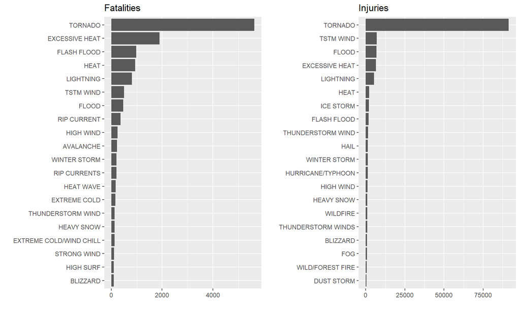

```r
fat <- eventype %>%
        top_n(20, fatalities) %>%
        ggplot() +
        geom_bar(aes(x=fatalities,
                     y=reorder(EVTYPE,+fatalities)),
                 stat="identity") +
        labs(title="Fatalities",x="",y="")

inj <- eventype %>%
        top_n(20, injuries) %>%
        ggplot() +
        geom_bar(aes(x=injuries,
                     y=reorder(EVTYPE,+injuries)),
                 stat="identity") +
        labs(title="Injuries",x="",y="")

# Plot code:

ggarrange(fat,inj, ncol = 2)
```

In terms of material damage

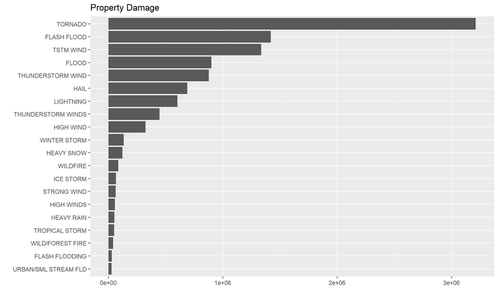

```r
eventype %>%
        top_n(20, propmg) %>%
        ggplot() +
        geom_bar(aes(x=propmg,
                     y=reorder(EVTYPE,+propmg)),
                 stat="identity") +
        labs(title="Property Damage",x="",y="")
```